# Valores Faltantes

Emanuel Fitta

2023-08-18

## Ejemplo imputación múltiple con MICE

```r
library(mice)
head(nhanes)
```

|  | age | bmi | hyp | chl |
| --- | --- | --- | --- | --- |
| 1 | 1 | NA | NA | NA |
| 2 | 2 | 22.7 | 1 | 187 |
| 3 | 1 | NA | 1 | 187 |
| 4 | 3 | NA | NA | NA |
| 5 | 1 | 20.4 | 1 | 113 |
| 6 | 3 | NA | NA | 184 |

Estos son los primeros 6 renglones de un total de 25 . Datos de la librería mice. age Age group (1=20-39, 2=40-59, 3=60+) bmi Body mass index (kg/m**2) hyp Hypertensive (1=no,2=yes) chl Total serum cholesterol (mg/dL)

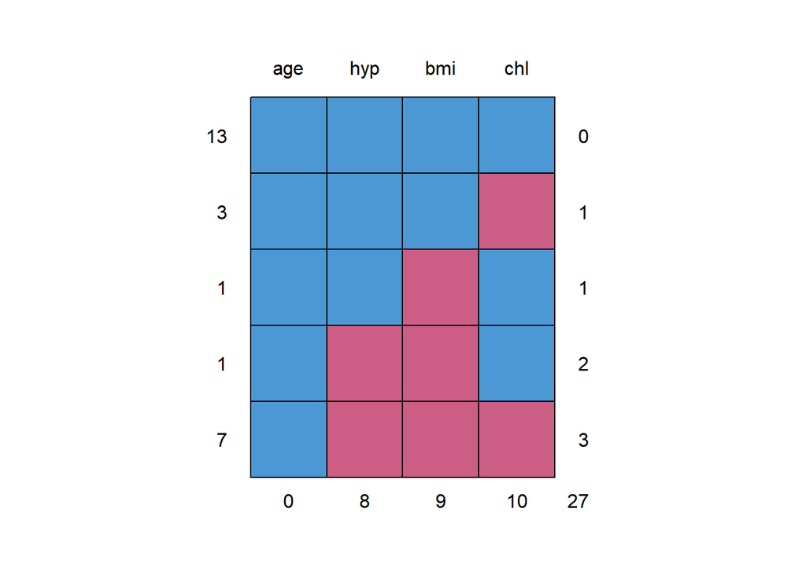

```
##    age hyp bmi chl
## 13   1   1   1   1  0
## 3    1   1   1   0  1
## 1    1   1   0   1  1
## 1    1   0   0   1  2
## 7    1   0   0   0  3
##      0   8   9  10 27
```

```r
md.pattern(nhanes)
```

13 observaciones completas 3 que les falta medición de chl 1 que le falta bmi ,; 1 que le faltan hyp y bmi 7 que les faltan hyp, bmi y chl (7 × 3) + (1 × 2) + (3 × 1) + (1 × 1) = 27

Este es el comando para correr la imputación múltiple.

```r
imp <- mice(nhanes, seed = 23109, print = FALSE)
print(imp)
```

```
## Class: mids
## Number of multiple imputations:  5
## Imputation methods:
##   age   bmi   hyp   chl
##    "" "pmm" "pmm" "pmm"
## PredictorMatrix:
##     age bmi hyp chl
## age   0   1   1   1
## bmi   1   0   1   1
## hyp   1   1   0   1
## chl   1   1   1   0
```

Habrá 5 juegos de datos Por ejemplo la variable bmi será modelada a través de age+hyp+chl

Hay 9 valores faltantes de bmi Aquí están los 5 juegos de 9 imputaciones

```r
imp$imp$bmi
```

|  | 1 | 2 | 3 | 4 | 5 |
| --- | --- | --- | --- | --- | --- |
| 1 | 27.2 | 27.2 | 29.6 | 27.4 | 20.4 |
| 3 | 27.2 | 27.2 | 29.6 | 35.3 | 27.2 |
| 4 | 24.9 | 25.5 | 25.5 | 20.4 | 22.0 |
| 6 | 21.7 | 21.7 | 20.4 | 27.4 | 25.5 |
| 10 | 22.5 | 22.5 | 22.5 | 33.2 | 26.3 |
| 11 | 29.6 | 27.2 | 27.2 | 35.3 | 33.2 |
| 12 | 22.0 | 25.5 | 27.2 | 30.1 | 28.7 |
| 16 | 35.3 | 27.2 | 35.3 | 29.6 | 27.2 |
| 21 | 28.7 | 25.5 | 22.5 | 33.2 | 20.4 |

Hay 8 valores faltantes de hyp Aquí están los 5 juegos de 8 imputaciones

```r
imp$imp$hyp
```

|  | 1 | 2 | 3 | 4 | 5 |
| --- | --- | --- | --- | --- | --- |
| 1 | 1 | 1 | 2 | 1 | 1 |
| 4 | 1 | 2 | 2 | 1 | 2 |
| 6 | 2 | 2 | 1 | 1 | 2 |
| 10 | 1 | 1 | 1 | 1 | 1 |
| 11 | 1 | 1 | 1 | 1 | 1 |
| 12 | 1 | 1 | 2 | 1 | 1 |
| 16 | 1 | 1 | 1 | 2 | 2 |
| 21 | 1 | 1 | 1 | 2 | 1 |

Este es un juego de datos completos. (el primero)

```r
complete(imp)
```

|  | age | bmi | hyp | chl |
| --- | --- | --- | --- | --- |
| 1 | 1 | 27.2 | 1 | 238 |
| 2 | 2 | 22.7 | 1 | 187 |
| 3 | 1 | 27.2 | 1 | 187 |
| 4 | 3 | 24.9 | 1 | 184 |
| 5 | 1 | 20.4 | 1 | 113 |
| 6 | 3 | 21.7 | 2 | 184 |
| 7 | 1 | 22.5 | 1 | 118 |
| 8 | 1 | 30.1 | 1 | 187 |
| 9 | 2 | 22.0 | 1 | 238 |
| 10 | 2 | 22.5 | 1 | 187 |

[output cut: 15 more lines]

Visualización de datos faltantes por variable

```r
library(lattice)
```

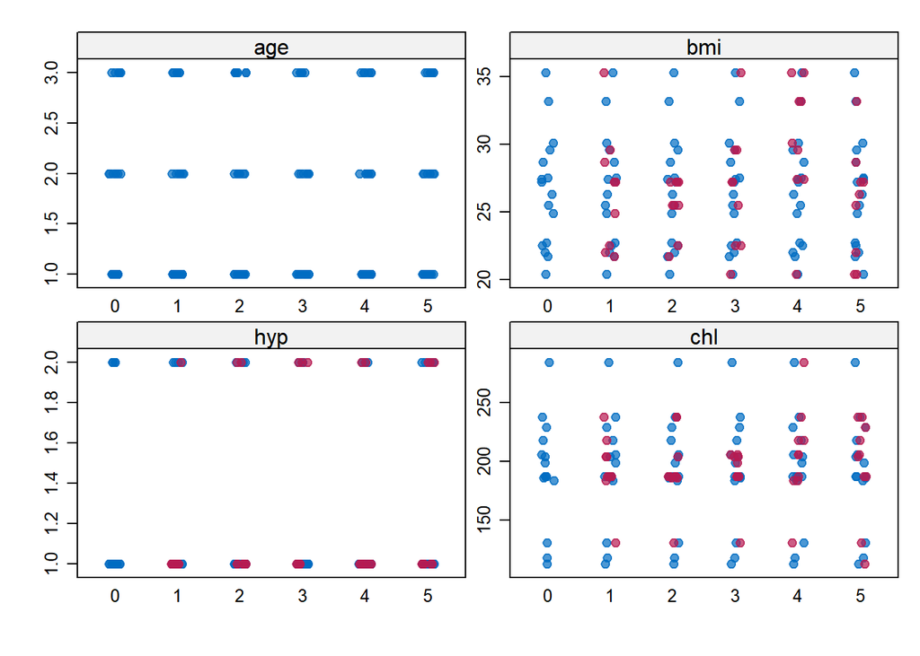

```r
stripplot(imp, pch = 20, cex = 1.2)
```

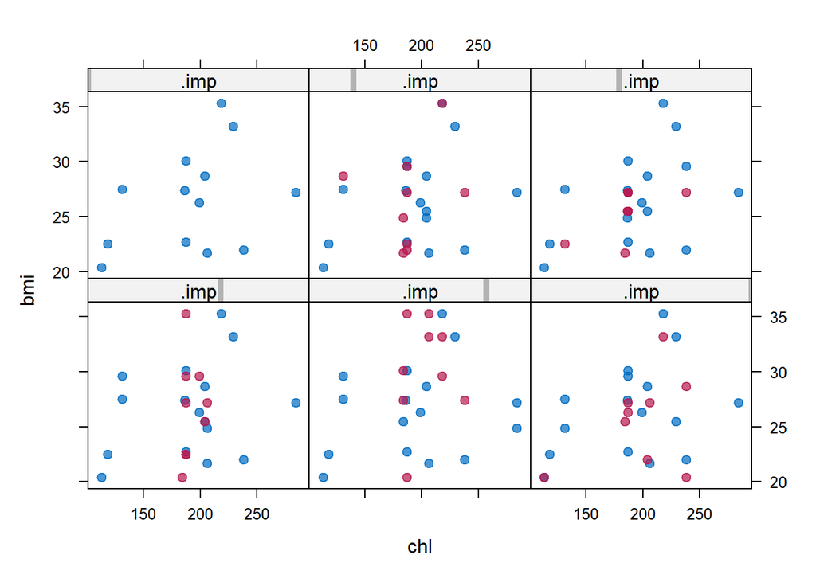

```r
xyplot(imp, bmi ~ chl | .imp, pch = 20, cex = 1.4)
```

Si la idea es correr un análisis de regresión para explicar los niveles de colesterol en función de la edad y el índice de masa corporal, este paquete mice permite hacerlo así.

```r
fit <- with(imp, lm(chl ~ age + bmi))
print(pool(fit))
```

```
## Class: mipo    m = 5
##          term m   estimate       ubar          b           t dfcom       df
## 1 (Intercept) 5  0.2189968 3282.24819 580.093104 3978.359911    22 14.80613
## 2         age 5 28.0471913   82.33144  25.620278  113.075773    22 11.58238
## 3         bmi 5  5.3831348    3.28861   1.028738    4.523096    22 11.55051
##         riv    lambda       fmi
## 1 0.2120838 0.1749745 0.2676421
## 2 0.3734215 0.2718914 0.3717528
## 3 0.3753822 0.2729294 0.3728669
```

Este es el estimador combinado $\hat{\gamma} = \Sigma_{i = 1} ^ {D} \gamma_i /D$

Esta es la varianza del estimador combinado $T_D = \hat{U}_D + (1 + 1/D)B_D$ con
$$\hat{U}_D = \Sigma_{i = 1} ^ {D} U_i/D \quad
\text{(Promedio de varianzas)}$$
y

$$B_D = \Sigma_{i = 1}^{D}(\hat{\gamma}_i
- \hat{\gamma})^2/(D-1) \quad \text{(Varianza entre
imputaciones)}$$